# Instacart EDA

Germayne

```r
library(tidyverse)
library(data.table)
```

```r
path <- "D:\\kaggle\\instacart\\raw_data"
aisles <- fread(file.path(path, "aisles.csv"))
departments <- fread(file.path(path, "departments.csv"))
orderp <- fread(file.path(path, "order_products__prior.csv"))
```

```
Read 0.0% of 32434489 rows
Read 10.3% of 32434489 rows
Read 22.9% of 32434489 rows
Read 35.6% of 32434489 rows
Read 48.0% of 32434489 rows
Read 60.6% of 32434489 rows
Read 73.2% of 32434489 rows
Read 85.7% of 32434489 rows
Read 98.2% of 32434489 rows
Read 32434489 rows and 4 (of 4) columns from 0.538 GB file in 00:00:14
```

```r
ordert <- fread(file.path(path, "order_products__train.csv"))
orders <- fread(file.path(path, "orders.csv"))
```

```
Read 37.1% of 3421083 rows
Read 76.3% of 3421083 rows
Read 3421083 rows and 7 (of 7) columns from 0.101 GB file in 00:00:04
```

```r
products <- fread(file.path(path, "products.csv"))
# convert some of the data types
aisles$aisle <- as.factor(aisles$aisle)
departments$department <- as.factor(departments$department)
orders$eval_set <- as.factor(orders$eval_set)
products$product_name <- as.factor(products$product_name)
```

# Preliminary Exploratory

Let us have a first look at the data structures for each files since there are many files in this competition.

## Aisles

Aisles are simply the different food categories (passage) of a grocery store.

```r
head(aisles,30)
```

| aisle_id | aisle |
| --- | --- |
| 1 | prepared soups salads |
| 2 | specialty cheeses |
| 3 | energy granola bars |
| 4 | instant foods |
| 5 | marinades meat preparation |
| 6 | other |
| 7 | packaged meat |
| 8 | bakery desserts |
| 9 | pasta sauce |
| 10 | kitchen supplies |

[output cut: 20 more lines]

```r
glimpse(aisles)
```

```
Observations: 134
Variables: 2
$ aisle_id <int> 1, 2, 3, 4, 5, 6, 7, 8, 9, 10, 11, 12, 13, 14, 15, 16, 17, 18, 19, 20, 21, 22, 23, 24, 2...
$ aisle    <fctr> prepared soups salads, specialty cheeses, energy granola bars, instant foods, marinades...
```

```r
summary(aisles)
```

```
    aisle_id                         aisle
 Min.   :  1.00   air fresheners candles:  1
 1st Qu.: 34.25   asian foods           :  1
 Median : 67.50   baby accessories      :  1
 Mean   : 67.50   baby bath body care   :  1
 3rd Qu.:100.75   baby food formula     :  1
 Max.   :134.00   bakery desserts       :  1
                  (Other)               :128
```

```r
length(unique(aisles$aisle_id))
```

```
[1] 134
```

## Departments

I will think of departments as a broader categorization as opposed to aisles.

```r
head(departments,30)
```

| department_id | department |
| --- | --- |
| 1 | frozen |
| 2 | other |
| 3 | bakery |
| 4 | produce |
| 5 | alcohol |
| 6 | international |
| 7 | beverages |
| 8 | pets |
| 9 | dry goods pasta |
| 10 | bulk |

[output cut: 11 more lines]

```r
glimpse(departments)
```

```
Observations: 21
Variables: 2
$ department_id <int> 1, 2, 3, 4, 5, 6, 7, 8, 9, 10, 11, 12, 13, 14, 15, 16, 17, 18, 19, 20, 21
$ department    <fctr> frozen, other, bakery, produce, alcohol, international, beverages, pets, dry goods...
```

```r
summary(departments)
```

```
 department_id     department
 Min.   : 1    alcohol  : 1
 1st Qu.: 6    babies   : 1
 Median :11    bakery   : 1
 Mean   :11    beverages: 1
 3rd Qu.:16    breakfast: 1
 Max.   :21    bulk     : 1
               (Other)  :15
```

## Order Prior

```r
head(orderp,30)
```

| order_id | product_id | add_to_cart_order | reordered |
| --- | --- | --- | --- |
| 2 | 33120 | 1 | 1 |
| 2 | 28985 | 2 | 1 |
| 2 | 9327 | 3 | 0 |
| 2 | 45918 | 4 | 1 |
| 2 | 30035 | 5 | 0 |
| 2 | 17794 | 6 | 1 |
| 2 | 40141 | 7 | 1 |
| 2 | 1819 | 8 | 1 |
| 2 | 43668 | 9 | 0 |
| 3 | 33754 | 1 | 1 |

[output cut: 20 more lines]

```r
glimpse(orderp)
```

```
Observations: 32,434,489
Variables: 4
$ order_id          <int> 2, 2, 2, 2, 2, 2, 2, 2, 2, 3, 3, 3, 3, 3, 3, 3, 3, 4, 4, 4, 4, 4, 4, 4, 4, 4, 4, 4...
$ product_id        <int> 33120, 28985, 9327, 45918, 30035, 17794, 40141, 1819, 43668, 33754, 24838, 17704, ...
$ add_to_cart_order <int> 1, 2, 3, 4, 5, 6, 7, 8, 9, 1, 2, 3, 4, 5, 6, 7, 8, 1, 2, 3, 4, 5, 6, 7, 8, 9, 10, ...
$ reordered         <int> 1, 1, 0, 1, 0, 1, 1, 1, 0, 1, 1, 1, 1, 1, 1, 1, 1, 0, 1, 1, 1, 1, 1, 1, 1, 1, 1, 1...
```

```r
summary(orderp)
```

```
    order_id         product_id    add_to_cart_order   reordered
 Min.   :      2   Min.   :    1   Min.   :  1.000   Min.   :0.0000
 1st Qu.: 855943   1st Qu.:13530   1st Qu.:  3.000   1st Qu.:0.0000
 Median :1711048   Median :25256   Median :  6.000   Median :1.0000
 Mean   :1710749   Mean   :25576   Mean   :  8.351   Mean   :0.5897
 3rd Qu.:2565514   3rd Qu.:37935   3rd Qu.: 11.000   3rd Qu.:1.0000
 Max.   :3421083   Max.   :49688   Max.   :145.000   Max.   :1.0000
```

## Order train

```r
head(ordert,10)
```

| order_id | product_id | add_to_cart_order | reordered |
| --- | --- | --- | --- |
| 1 | 49302 | 1 | 1 |
| 1 | 11109 | 2 | 1 |
| 1 | 10246 | 3 | 0 |
| 1 | 49683 | 4 | 0 |
| 1 | 43633 | 5 | 1 |
| 1 | 13176 | 6 | 0 |
| 1 | 47209 | 7 | 0 |
| 1 | 22035 | 8 | 1 |
| 36 | 39612 | 1 | 0 |
| 36 | 19660 | 2 | 1 |

```r
glimpse(ordert)
```

```
Observations: 1,384,617
Variables: 4
$ order_id          <int> 1, 1, 1, 1, 1, 1, 1, 1, 36, 36, 36, 36, 36, 36, 36, 36, 38, 38, 38, 38, 38, 38,...
$ product_id        <int> 49302, 11109, 10246, 49683, 43633, 13176, 47209, 22035, 39612, 19660, 49235, 43...
$ add_to_cart_order <int> 1, 2, 3, 4, 5, 6, 7, 8, 1, 2, 3, 4, 5, 6, 7, 8, 1, 2, 3, 4, 5, 6, 7, 8, 9, 1, 2...
$ reordered         <int> 1, 1, 0, 0, 1, 0, 0, 1, 0, 1, 0, 1, 1, 1, 1, 1, 0, 0, 0, 1, 0, 0, 0, 0, 0, 1, 0...
```

```r
summary(ordert)
```

```
    order_id         product_id    add_to_cart_order   reordered
 Min.   :      1   Min.   :    1   Min.   : 1.000    Min.   :0.0000
 1st Qu.: 843370   1st Qu.:13380   1st Qu.: 3.000    1st Qu.:0.0000
 Median :1701880   Median :25298   Median : 7.000    Median :1.0000
 Mean   :1706298   Mean   :25556   Mean   : 8.758    Mean   :0.5986
 3rd Qu.:2568023   3rd Qu.:37940   3rd Qu.:12.000    3rd Qu.:1.0000
 Max.   :3421070   Max.   :49688   Max.   :80.000    Max.   :1.0000
```

## Order

```r
head(orders,30)
```

| order_id | user_id | eval_set | order_number | order_dow | order_hour_of_day | days_since_prior_order |
| --- | --- | --- | --- | --- | --- | --- |
| 2539329 | 1 | prior | 1 | 2 | 8 | NA |
| 2398795 | 1 | prior | 2 | 3 | 7 | 15 |
| 473747 | 1 | prior | 3 | 3 | 12 | 21 |
| 2254736 | 1 | prior | 4 | 4 | 7 | 29 |
| 431534 | 1 | prior | 5 | 4 | 15 | 28 |
| 3367565 | 1 | prior | 6 | 2 | 7 | 19 |
| 550135 | 1 | prior | 7 | 1 | 9 | 20 |
| 3108588 | 1 | prior | 8 | 1 | 14 | 14 |
| 2295261 | 1 | prior | 9 | 1 | 16 | 0 |
| 2550362 | 1 | prior | 10 | 4 | 8 | 30 |

[output cut: 20 more lines]

```r
summary(orders)
```

```
    order_id          user_id        eval_set        order_number      order_dow     order_hour_of_day
 Min.   :      1   Min.   :     1   prior:3214874   Min.   :  1.00   Min.   :0.000   Min.   : 0.00
 1st Qu.: 855272   1st Qu.: 51394   test :  75000   1st Qu.:  5.00   1st Qu.:1.000   1st Qu.:10.00
 Median :1710542   Median :102689   train: 131209   Median : 11.00   Median :3.000   Median :13.00
 Mean   :1710542   Mean   :102978                   Mean   : 17.15   Mean   :2.776   Mean   :13.45
 3rd Qu.:2565812   3rd Qu.:154385                   3rd Qu.: 23.00   3rd Qu.:5.000   3rd Qu.:16.00
 Max.   :3421083   Max.   :206209                   Max.   :100.00   Max.   :6.000   Max.   :23.00

 days_since_prior_order
 Min.   : 0.00
 1st Qu.: 4.00
 Median : 7.00
 Mean   :11.11
 3rd Qu.:15.00
 Max.   :30.00
 NA's   :206209
```

## Products

```r
head(products,30)
```

| product_id | product_name | aisle_id | department_id |
| --- | --- | --- | --- |
| 1 | Chocolate Sandwich Cookies | 61 | 19 |
| 2 | All-Seasons Salt | 104 | 13 |
| 3 | Robust Golden Unsweetened Oolong Tea | 94 | 7 |
| 4 | Smart Ones Classic Favorites Mini Rigatoni With Vodka Cream Sauce | 38 | 1 |
| 5 | Green Chile Anytime Sauce | 5 | 13 |
| 6 | Dry Nose Oil | 11 | 11 |
| 7 | Pure Coconut Water With Orange | 98 | 7 |
| 8 | Cut Russet Potatoes Steam N' Mash | 116 | 1 |
| 9 | Light Strawberry Blueberry Yogurt | 120 | 16 |
| 10 | Sparkling Orange Juice & Prickly Pear Beverage | 115 | 7 |

[output cut: 20 more lines]

```r
glimpse(products)
```

```
Observations: 49,688
Variables: 4
$ product_id    <int> 1, 2, 3, 4, 5, 6, 7, 8, 9, 10, 11, 12, 13, 14, 15, 16, 17, 18, 19, 20, 21, 22, 23, ...
$ product_name  <fctr> Chocolate Sandwich Cookies, All-Seasons Salt, Robust Golden Unsweetened Oolong Tea...
$ aisle_id      <int> 61, 104, 94, 38, 5, 11, 98, 116, 120, 115, 31, 119, 11, 74, 56, 103, 35, 79, 63, 98...
$ department_id <int> 19, 13, 7, 1, 13, 11, 7, 1, 16, 7, 7, 1, 11, 17, 18, 19, 12, 1, 9, 7, 8, 11, 12, 11...
```

# Reshape, combine data structure

Note that we have 6 data set, and we must restructure them. This image will summarize the data structures:

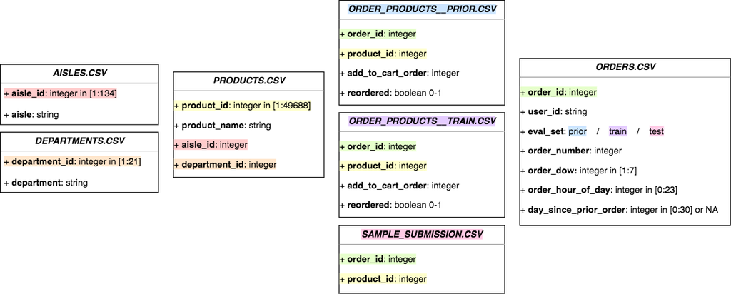

By looking at the orders dataset, users are categorized as train user and test user. And each user have a list of prior orders, which we can do features engineering on.

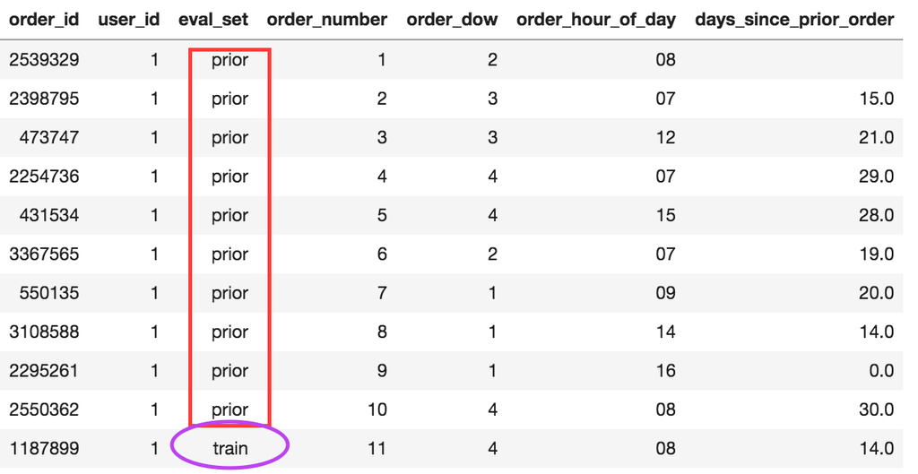

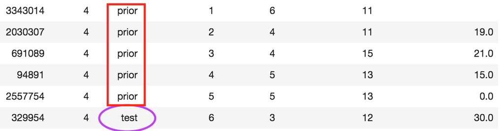

## Products dataframe

Let us first combine **products**, **departments** as well as **aisles** into one dataframe.

```r
products <- products %>%
  inner_join(aisles) %>% inner_join(departments)
#%>% select(-aisle_id, -department_id)
rm(aisles, departments)
```

Let us view this new products dataframe

```r
head(products,30)
```

|  | product_id | product_name | aisle_id | department_id | aisle | department |
| --- | --- | --- | --- | --- | --- | --- |
| 1 | 1 | Chocolate Sandwich Cookies | 61 | 19 | cookies cakes | snacks |
| 2 | 2 | All-Seasons Salt | 104 | 13 | spices seasonings | pantry |
| 3 | 3 | Robust Golden Unsweetened Oolong Tea | 94 | 7 | tea | beverages |
| 4 | 4 | Smart Ones Classic Favorites Mini Rigatoni With Vodka Cream Sauce | 38 | 1 | frozen meals | frozen |
| 5 | 5 | Green Chile Anytime Sauce | 5 | 13 | marinades meat preparation | pantry |
| 6 | 6 | Dry Nose Oil | 11 | 11 | cold flu allergy | personal care |
| 7 | 7 | Pure Coconut Water With Orange | 98 | 7 | juice nectars | beverages |
| 8 | 8 | Cut Russet Potatoes Steam N' Mash | 116 | 1 | frozen produce | frozen |
| 9 | 9 | Light Strawberry Blueberry Yogurt | 120 | 16 | yogurt | dairy eggs |
| 10 | 10 | Sparkling Orange Juice & Prickly Pear Beverage | 115 | 7 | water seltzer sparkling water | beverages |

[output cut: 20 more lines]

**so far this data is not used. We can make use of this.**

## Create orders_products

Let us combine orders with order prior using inner join via their order id.

This will be the list of prior orders with its product information.

```r
orders_products <- orders %>% inner_join(orderp, by = "order_id") # combine data such that similar rows exist
```

```r
head(orders_products,30)
```

|  | order_id | user_id | eval_set | order_number | order_dow | order_hour_of_day | days_since_prior_order | product_id | add_to_cart_order | reordered |
| --- | --- | --- | --- | --- | --- | --- | --- | --- | --- | --- |
| 1 | 2539329 | 1 | prior | 1 | 2 | 8 | NA | 196 | 1 | 0 |
| 2 | 2539329 | 1 | prior | 1 | 2 | 8 | NA | 14084 | 2 | 0 |
| 3 | 2539329 | 1 | prior | 1 | 2 | 8 | NA | 12427 | 3 | 0 |
| 4 | 2539329 | 1 | prior | 1 | 2 | 8 | NA | 26088 | 4 | 0 |
| 5 | 2539329 | 1 | prior | 1 | 2 | 8 | NA | 26405 | 5 | 0 |
| 6 | 2398795 | 1 | prior | 2 | 3 | 7 | 15 | 196 | 1 | 1 |
| 7 | 2398795 | 1 | prior | 2 | 3 | 7 | 15 | 10258 | 2 | 0 |
| 8 | 2398795 | 1 | prior | 2 | 3 | 7 | 15 | 12427 | 3 | 1 |
| 9 | 2398795 | 1 | prior | 2 | 3 | 7 | 15 | 13176 | 4 | 0 |
| 10 | 2398795 | 1 | prior | 2 | 3 | 7 | 15 | 26088 | 5 | 1 |

[output cut: 20 more lines]

```r
colnames(orders_products)
```

```
 [1] "order_id"               "user_id"                "eval_set"               "order_number"
 [5] "order_dow"              "order_hour_of_day"      "days_since_prior_order" "product_id"
 [9] "add_to_cart_order"      "reordered"
```

## Product features of prior orders (from orders_products)

Some features based on unique products id:

- prod_orders: total number of orders from unique users
- prod_reorders: total number of reorders from all users (may be repeated)
- prod_first_orders: total number of first orders from all unique users (based on product_time)
- prod_second_orders: total number of second orders from all unique users (based on product_time)